# Homework 02 - Data Visualization, Wrangling and Advanced Regression

Sophie Xu

February 16, 2025

### Introduction

This assignment examines the relationship between alcohol consumption and life expectancy through data analysis. The primary questions of interest are: * Is there an association between life expectancy and alcohol consumption? * Is there a difference in the association between life expectancy and alcohol for males and females? * How have life expectancy and alcohol consumption changed over time? To answer these questions, we perform data wrangling, visualization, and regression analysis.

### 1 Data Wrangling

For both datasets, we renamed variables for clarity and extracted relevant variables: country, country code, population, year, sex, life expectancy, and alcohol consumption. In the life expectancy dataset, we consolidated male and female life expectancy into a single column with a corresponding sex variable. The data spans from 1950 to 2023, though some population and life expectancy values are missing. For the alcohol consumption dataset, we excluded records labeled “both sexes” for simplicity. This dataset spans from 2000 to 2019 and has no missing values. We also categorized alcohol consumption into levels based on quartiles. After merging the datasets by country, sex, and year, we obtained a final dataset with 7,492 observations.

|  | Code | Year | Sex | Population | Life Expectancy | Country | Consumption |
| --- | --- | --- | --- | --- | --- | --- | --- |
|  | Length:7492 | Min. :2000 | Length:7492 | Min. :1.776e+03 | Min. :12.38 | Length:7492 | Min. : 0.000 |
|  | Class :character | 1st Qu.:2005 | Class :character | 1st Qu.:1.967e+06 | 1st Qu.:63.34 | Class :character | 1st Qu.: 1.330 |
|  | Mode :character | Median :2010 | Mode :character | Median :7.598e+06 | Median :70.74 | Mode :character | Median : 3.700 |
|  | NA | Mean :2010 | NA | Mean :3.680e+07 | Mean :69.64 | NA | Mean : 5.966 |
|  | NA | 3rd Qu.:2015 | NA | 3rd Qu.:2.481e+07 | 3rd Qu.:77.10 | NA | 3rd Qu.: 8.900 |
|  | NA | Max. :2019 | NA | Max. :1.424e+09 | Max. :87.43 | NA | Max. :31.440 |

| Stage | Number of Observations |
| --- | --- |
| Life Expectancy: Before Merge | 18978 |
| Life Expectancy: After Collapsing Sex | 37956 |
| Alcohol: Before Filter | 11238 |
| Alcohol: After filter | 7492 |
| Data: After Merge | 7492 |

| Year | Sex | Mean Life Expectancy | SD Life Expectancy | Mean Alcohol Consumption | SD Alcohol Consumption |
| --- | --- | --- | --- | --- | --- |
| 2000 | Female | 69.142 | 10.284 | 2.541 | 2.173 |
| 2000 | Male | 64.038 | 9.129 | 9.287 | 7.054 |
| 2001 | Female | 69.467 | 10.273 | 2.541 | 2.173 |
| 2001 | Male | 64.364 | 9.122 | 9.287 | 7.054 |
| 2002 | Female | 69.757 | 10.173 | 2.533 | 2.170 |
| 2002 | Male | 64.673 | 9.060 | 9.248 | 7.035 |
| 2003 | Female | 70.090 | 10.060 | 2.531 | 2.163 |
| 2003 | Male | 65.029 | 8.981 | 9.221 | 6.986 |
| 2004 | Female | 70.405 | 9.982 | 2.553 | 2.167 |
| 2004 | Male | 65.359 | 8.921 | 9.277 | 6.965 |
| 2005 | Female | 70.792 | 9.862 | 2.585 | 2.188 |
| 2005 | Male | 65.702 | 8.842 | 9.363 | 7.011 |
| 2006 | Female | 71.150 | 9.722 | 2.620 | 2.201 |
| 2006 | Male | 66.015 | 8.736 | 9.461 | 7.046 |
| 2007 | Female | 71.544 | 9.499 | 2.674 | 2.221 |
| 2007 | Male | 66.388 | 8.582 | 9.641 | 7.140 |
| 2008 | Female | 71.856 | 9.387 | 2.638 | 2.176 |
| 2008 | Male | 66.728 | 8.473 | 9.532 | 7.019 |
| 2009 | Female | 72.046 | 9.810 | 2.597 | 2.106 |
| 2009 | Male | 66.903 | 9.142 | 9.431 | 6.839 |
| 2010 | Female | 72.445 | 9.256 | 2.568 | 2.047 |
| 2010 | Male | 67.363 | 8.462 | 9.369 | 6.682 |
| 2011 | Female | 72.783 | 9.179 | 2.585 | 2.038 |
| 2011 | Male | 67.679 | 8.466 | 9.447 | 6.673 |
| 2012 | Female | 73.146 | 8.662 | 2.586 | 2.030 |
| 2012 | Male | 68.045 | 8.061 | 9.455 | 6.662 |
| 2013 | Female | 73.468 | 8.478 | 2.572 | 2.003 |
| 2013 | Male | 68.355 | 7.967 | 9.429 | 6.597 |
| 2014 | Female | 73.717 | 8.468 | 2.550 | 1.969 |
| 2014 | Male | 68.545 | 8.101 | 9.372 | 6.502 |
| 2015 | Female | 73.955 | 8.162 | 2.538 | 1.946 |
| 2015 | Male | 68.811 | 7.770 | 9.350 | 6.446 |
| 2016 | Female | 74.235 | 8.016 | 2.525 | 1.929 |
| 2016 | Male | 69.060 | 7.672 | 9.322 | 6.408 |
| 2017 | Female | 74.429 | 7.970 | 2.517 | 1.916 |
| 2017 | Male | 69.234 | 7.742 | 9.300 | 6.385 |
| 2018 | Female | 74.733 | 7.755 | 2.510 | 1.913 |
| 2018 | Male | 69.528 | 7.476 | 9.282 | 6.383 |
| 2019 | Female | 74.845 | 7.949 | 2.510 | 1.913 |
| 2019 | Male | 69.635 | 7.897 | 9.282 | 6.383 |

| Sex | Consumption Level | Min Consumption | Max Consumption | Number of Observations |
| --- | --- | --- | --- | --- |
| Female | Low | 0.00 | 0.71 | 948 |
| Female | Medium | 0.72 | 3.99 | 1864 |
| Female | High | 4.00 | 9.69 | 934 |
| Male | Low | 0.00 | 3.25 | 937 |
| Male | Medium | 3.26 | 14.48 | 1872 |
| Male | High | 14.49 | 31.44 | 937 |

### 2 Exploring the Data

We first examined variable types and converted character variables to factors for ease of use. We confirmed that each country has a unique country code but found missing data for two countries between 2000 and 2006, which we chose to retain. A summary of the dataset revealed a balanced distribution of sexes, a wide range of life expectancy (12.38 to 87.43 years), and most observations falling into the medium alcohol consumption category. Exploratory visualizations supported these findings. A histogram of life expectancy by alcohol consumption level indicated that life expectancy modes were similar across all three consumption levels, suggesting that alcohol consumption may not be a strong predictor of life expectancy variation.

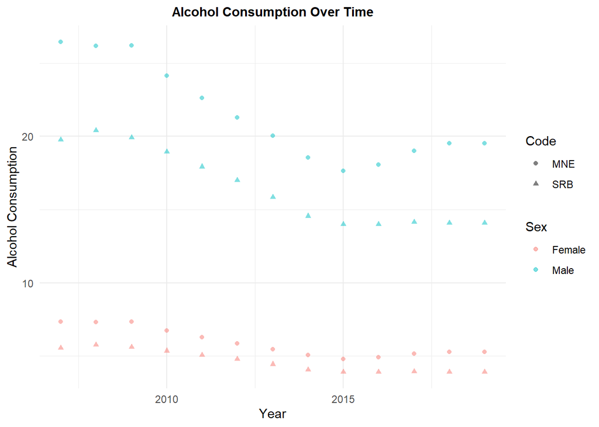

|  | Code | Year | Sex | Population | Life Expectancy | Country | Consumption | Consumption Level |
| --- | --- | --- | --- | --- | --- | --- | --- | --- |
|  | AFG : 40 | Min. :2000 | Female:3746 | Min. :1.776e+03 | Min. :12.38 | Afghanistan : 40 | Min. : 0.000 | Low :1885 |
|  | AGO : 40 | 1st Qu.:2005 | Male :3746 | 1st Qu.:1.967e+06 | 1st Qu.:63.34 | Albania : 40 | 1st Qu.: 1.330 | Medium:3736 |
|  | ALB : 40 | Median :2010 | NA | Median :7.598e+06 | Median :70.74 | Algeria : 40 | Median : 3.700 | High :1871 |
|  | AND : 40 | Mean :2010 | NA | Mean :3.680e+07 | Mean :69.64 | Andorra : 40 | Mean : 5.966 | NA |
|  | ARE : 40 | 3rd Qu.:2015 | NA | 3rd Qu.:2.481e+07 | 3rd Qu.:77.10 | Angola : 40 | 3rd Qu.: 8.900 | NA |
|  | ARG : 40 | Max. :2019 | NA | Max. :1.424e+09 | Max. :87.43 | Antigua and Barbuda: 40 | Max. :31.440 | NA |
|  | (Other):7252 | NA | NA | NA | NA | (Other) :7252 | NA | NA |

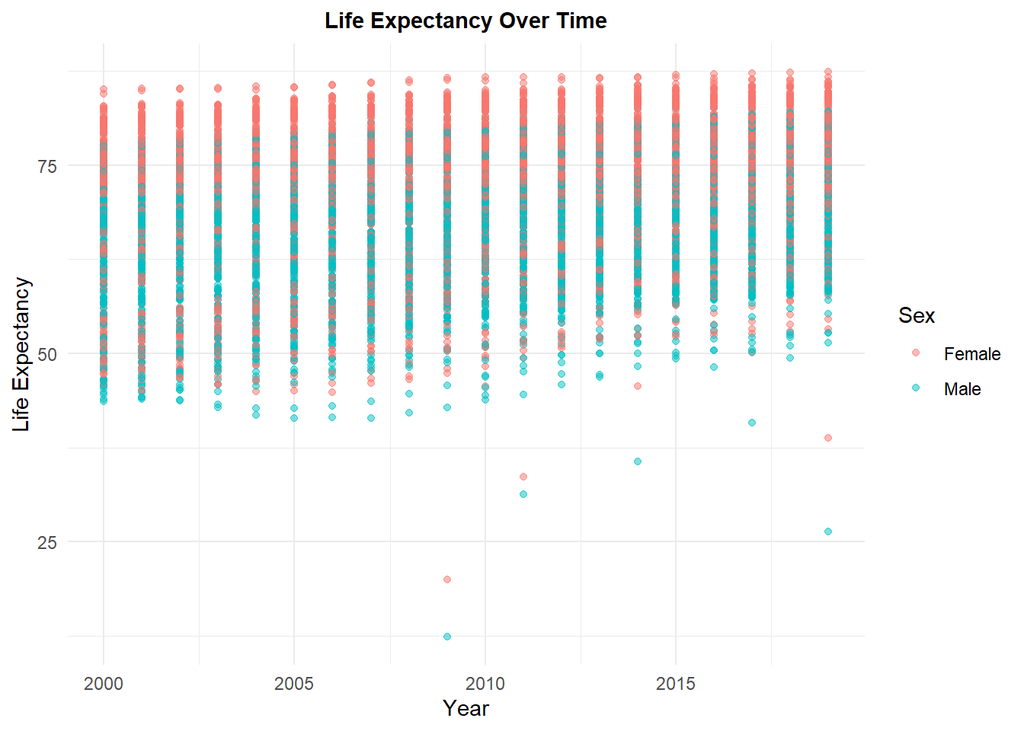

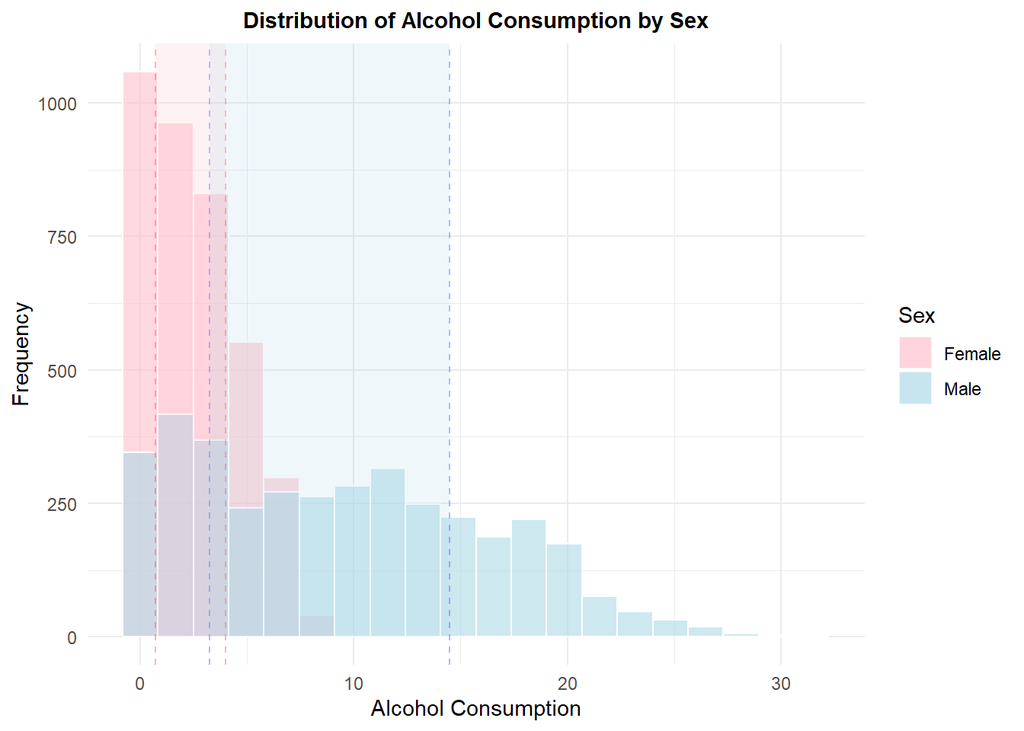

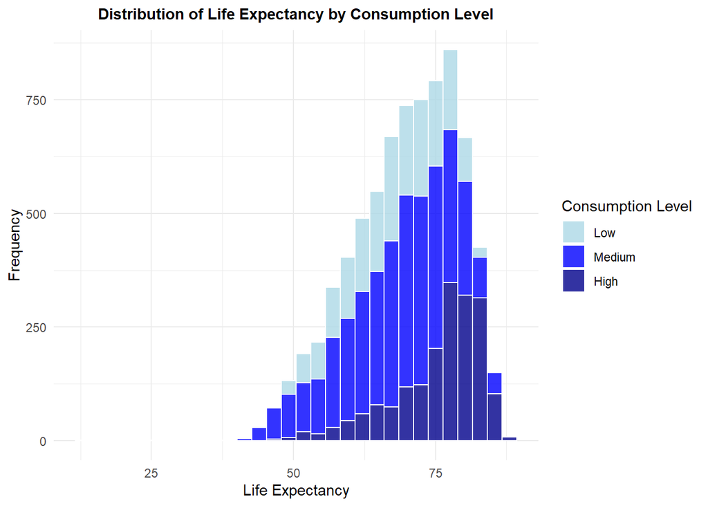

### 3 Visualization

After gaining insights into the data distribution, we created visualizations to examine the association between life expectancy and alcohol consumption, and the influence of sex and time. A stacked histogram of alcohol consumption by sex showed that females have a smaller range and variance in alcohol consumption compared to males.

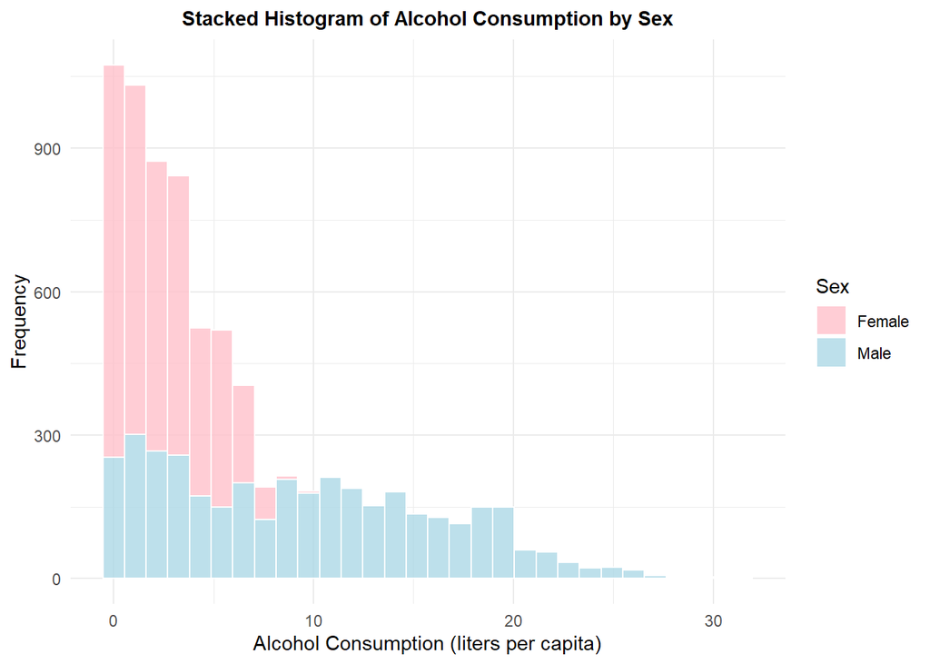

Scatterplots with linear regression lines for 2000, 2010, and 2019 indicated a positive correlation between alcohol consumption and life expectancy—higher alcohol consumption was associated with longer predicted life expectancy. However, over time, the fitted line became less steep, suggesting that an increasing amount of alcohol consumption is needed to observe the same increase in life expectancy.

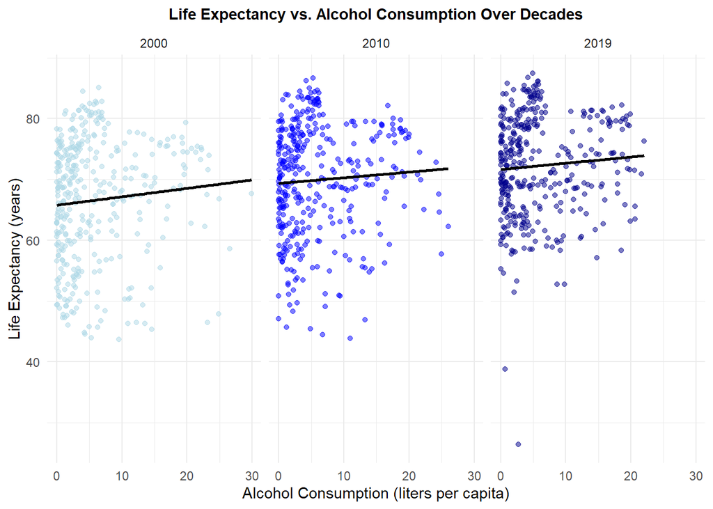

We then conducted a regression analysis of life expectancy over time, adjusting for sex, using data from Canada and Japan. The results revealed a strong positive correlation between life expectancy and time, with an adjusted R² of approximately 0.99. Additionally, sex was a significant predictor, with Japan showing a larger life expectancy gap between females and males (-6.57 years) than Canada (-4.48 years).

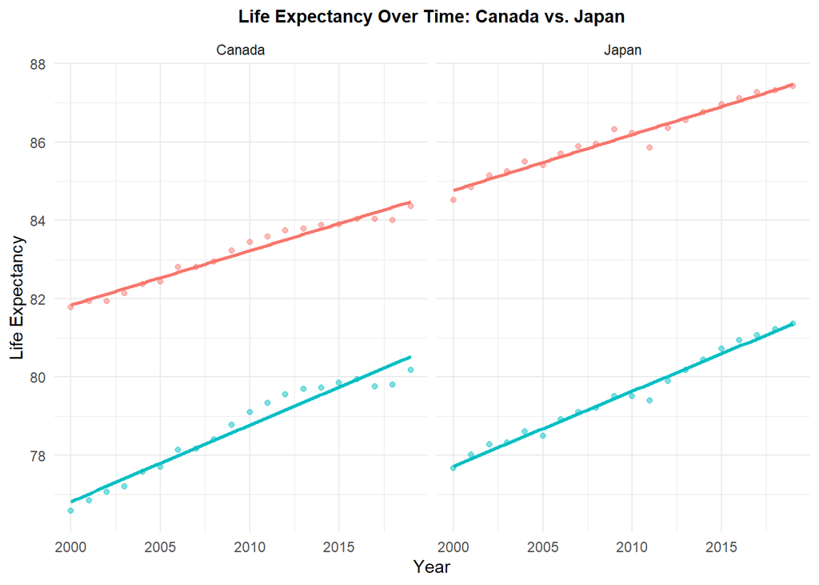

```
##
## Call:
## lm(formula = `Life Expectancy` ~ year_centered + Sex, data = df[df$Country ==
##     "Canada", ])
##
## Residuals:
##     Min      1Q  Median      3Q     Max
## -0.5651 -0.1859  0.0412  0.1946  0.4696
##
## Coefficients:
##                Estimate Std. Error t value Pr(>|t|)
## (Intercept)   81.576650   0.094223  865.78   <2e-16 ***
## year_centered  0.166300   0.007526   22.10   <2e-16 ***
## SexMale       -4.482800   0.086792  -51.65   <2e-16 ***
## ---
## Signif. codes:  0 '***' 0.001 '**' 0.01 '*' 0.05 '.' 0.1 ' ' 1
##
## Residual standard error: 0.2745 on 37 degrees of freedom
## Multiple R-squared:  0.9884, Adjusted R-squared:  0.9878
## F-statistic:  1578 on 2 and 37 DF,  p-value: < 2.2e-16
```

```
##
## Call:
## lm(formula = `Life Expectancy` ~ year_centered + Sex, data = df[df$Country ==
##     "Japan", ])
##
## Residuals:
##      Min       1Q   Median       3Q      Max
## -0.51535 -0.11378 -0.01519  0.16813  0.30515
##
## Coefficients:
##                Estimate Std. Error t value Pr(>|t|)
## (Intercept)   84.531304   0.071930 1175.19   <2e-16 ***
## year_centered  0.166731   0.005745   29.02   <2e-16 ***
## SexMale       -6.571150   0.066257  -99.18   <2e-16 ***
## ---
## Signif. codes:  0 '***' 0.001 '**' 0.01 '*' 0.05 '.' 0.1 ' ' 1
##
## Residual standard error: 0.2095 on 37 degrees of freedom
## Multiple R-squared:  0.9965, Adjusted R-squared:  0.9964
## F-statistic:  5339 on 2 and 37 DF,  p-value: < 2.2e-16
```

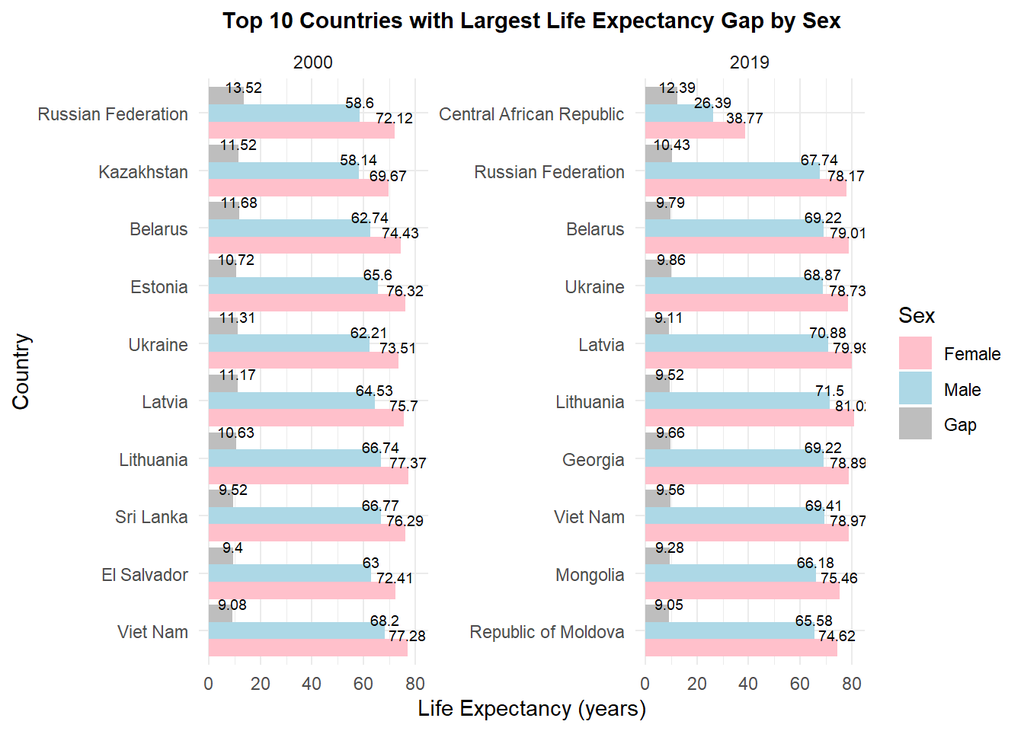

A boxplot of life expectancy by alcohol consumption level and sex in 2019 showed that medium and low consumption levels resulted in similar life expectancies, while high alcohol consumption was associated with significantly longer life expectancy. Interestingly, females in the high-consumption group exhibited lower variance in life expectancy compared to other groups.

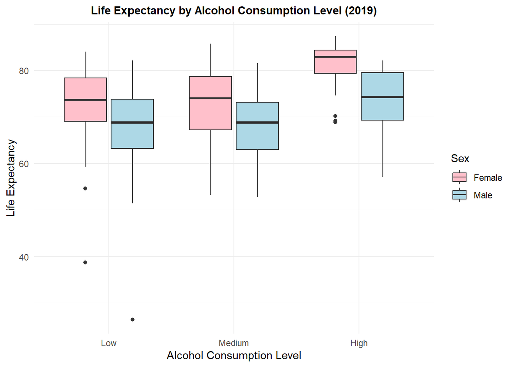

Finally, a scatterplot incorporating life expectancy, alcohol consumption, sex, and year illustrated that female data points were more clustered, reflecting their lower alcohol consumption variance. Additionally, life expectancy increased over time, as indicated by the progressive darkening of circle boundaries in the upper region of the data clusters. Among males, alcohol consumption appeared to decline over time, with darker-colored points concentrated on the left side of the plot.

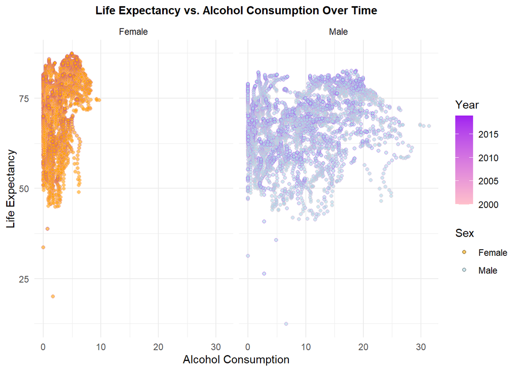

### 4 Advanced Regression

To quantitatively support our findings, we applied multiple regression models. We first fit both linear and cubic models to examine the relationship between life expectancy and alcohol consumption, adjusting for scaled population, year, and sex. Both models yielded similar results. The adjusted R² values (0.243 for the linear model and 0.296 for the cubic model) confirmed our hypothesis that alcohol consumption explains only a small portion of life expectancy variation. The regression results showed that, on average, a female with low alcohol consumption in 2000 had a life expectancy of ~71 years (linear) or ~68 years (cubic), adjusted for population. Medium consumption levels had a minimal, statistically insignificant effect, while high consumption levels significantly increased life expectancy by ~7.97 years (linear) or ~7.61 years (cubic). Over time, females with low alcohol consumption experienced an increase in life expectancy (~0.3 years) per year. Males with low alcohol consumption had a statistically significantly lower life expectancy than females (-5.13 years) in the same year.

```
##
## Call:
## lm(formula = Life_Expectancy ~ Consumption_Level + log(Population) +
##     year_centered + Sex, data = df)
##
## Residuals:
##     Min      1Q  Median      3Q     Max
## -52.700  -5.164   1.690   5.834  17.868
##
## Coefficients:
##                         Estimate Std. Error t value Pr(>|t|)
## (Intercept)             71.12265    0.73407  96.889  < 2e-16 ***
## Consumption_LevelMedium  0.19562    0.23200   0.843    0.399
## Consumption_LevelHigh    7.97289    0.26515  30.069  < 2e-16 ***
## log(Population)         -0.24881    0.04339  -5.734 1.02e-08 ***
## year_centered            0.30134    0.01630  18.487  < 2e-16 ***
## SexMale                 -5.13459    0.18766 -27.361  < 2e-16 ***
## ---
## Signif. codes:  0 '***' 0.001 '**' 0.01 '*' 0.05 '.' 0.1 ' ' 1
##
## Residual standard error: 8.122 on 7486 degrees of freedom
## Multiple R-squared:  0.2439, Adjusted R-squared:  0.2434
## F-statistic: 483.1 on 5 and 7486 DF,  p-value: < 2.2e-16
```

```
##
## Family: gaussian
## Link function: identity
##
## Formula:
## Life_Expectancy ~ Consumption_Level + s(log(Population), bs = "cr") +
##     year_centered + Sex
##
## Parametric coefficients:
##                         Estimate Std. Error t value Pr(>|t|)
## (Intercept)             67.52106    0.25096 269.051   <2e-16 ***
## Consumption_LevelMedium -0.20234    0.22847  -0.886    0.376
## Consumption_LevelHigh    7.61017    0.25920  29.360   <2e-16 ***
## year_centered            0.30346    0.01573  19.289   <2e-16 ***
## SexMale                 -5.13345    0.18097 -28.367   <2e-16 ***
## ---
## Signif. codes:  0 '***' 0.001 '**' 0.01 '*' 0.05 '.' 0.1 ' ' 1
##
## Approximate significance of smooth terms:
##                      edf Ref.df     F p-value
## s(log(Population)) 8.849  8.989 66.92  <2e-16 ***
## ---
## Signif. codes:  0 '***' 0.001 '**' 0.01 '*' 0.05 '.' 0.1 ' ' 1
##
## R-sq.(adj) =  0.296   Deviance explained = 29.8%
## GCV = 61.452  Scale est. = 61.338    n = 7492
```

We also plotted the smooth term for the GAM model. We can see the first peak (around log(Population) ≈ 12) suggests that at lower population levels, life expectancy increases. The dip around log(Population) ≈ 16 could indicate a point where larger populations correlate with lower life expectancy, but this needs deeper investigation. The increase at the right end (high population levels) suggests that the largest countries tend to have higher life expectancy.

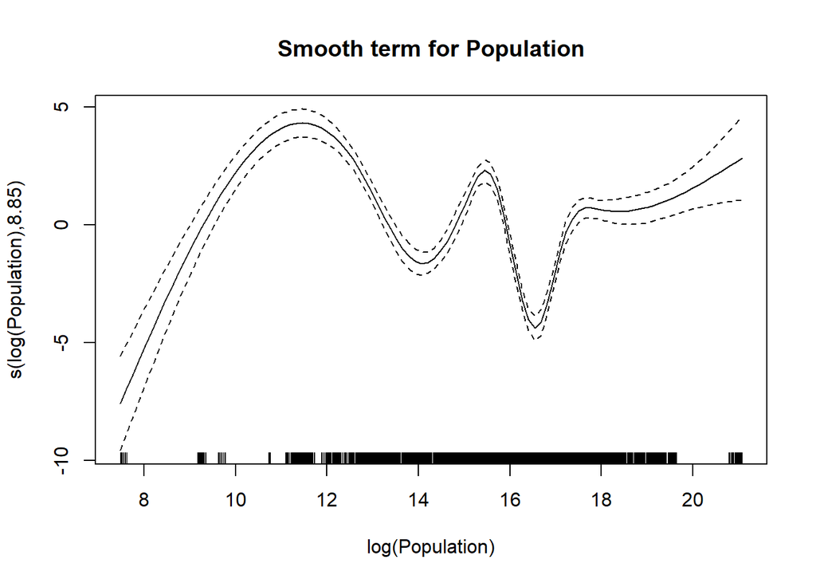

We further examined the relationship by averaging alcohol consumption and life expectancy over time. The predictability of the models declined, with adjusted R² values dropping to 0.160 (linear) and 0.207 (cubic). The results showed that, on average, a female with zero alcohol consumption from 2000–2019 had a life expectancy of ~73 years (linear) or ~71 years (cubic), adjusted for population. A one-unit increase in average alcohol consumption raised female life expectancy by ~0.54 years (linear) or ~0.51 years (cubic). The male-female life expectancy gap increased to ~8.8 years (linear) or ~8.6 years (cubic).

```
##
## Call:
## lm(formula = avg_life_expectancy ~ avg_consumption + log(avg_population) +
##     Sex, data = df_avg)
##
## Residuals:
##     Min      1Q  Median      3Q     Max
## -23.463  -5.456   1.806   6.110  15.993
##
## Coefficients:
##                     Estimate Std. Error t value Pr(>|t|)
## (Intercept)         72.70472    3.10825  23.391  < 2e-16 ***
## avg_consumption      0.53721    0.08758   6.134 2.20e-09 ***
## log(avg_population) -0.11928    0.19517  -0.611    0.541
## SexMale             -8.80052    1.04335  -8.435 7.43e-16 ***
## ---
## Signif. codes:  0 '***' 0.001 '**' 0.01 '*' 0.05 '.' 0.1 ' ' 1
##
## Residual standard error: 8.288 on 372 degrees of freedom
## Multiple R-squared:  0.1663, Adjusted R-squared:  0.1595
## F-statistic: 24.73 on 3 and 372 DF,  p-value: 1.303e-14
```

```
##
## Family: gaussian
## Link function: identity
##
## Formula:
## avg_life_expectancy ~ avg_consumption + s(log(avg_population),
##     bs = "cr") + Sex
##
## Parametric coefficients:
##                 Estimate Std. Error t value Pr(>|t|)
## (Intercept)     70.92026    0.62715 113.084  < 2e-16 ***
## avg_consumption  0.50959    0.08574   5.944 6.51e-09 ***
## SexMale         -8.61188    1.01595  -8.477 5.81e-16 ***
## ---
## Signif. codes:  0 '***' 0.001 '**' 0.01 '*' 0.05 '.' 0.1 ' ' 1
##
## Approximate significance of smooth terms:
##                          edf Ref.df     F p-value
## s(log(avg_population)) 8.094  8.665 3.055 0.00149 **
## ---
## Signif. codes:  0 '***' 0.001 '**' 0.01 '*' 0.05 '.' 0.1 ' ' 1
##
## R-sq.(adj) =  0.207   Deviance explained = 22.9%
## GCV = 66.759  Scale est. = 64.789    n = 376
```

These findings were reinforced by visualizations, where both linear and cubic regression lines indicated a positive relationship between average alcohol consumption and life expectancy. The cubic model better captured the relationship, particularly in the high-consumption region with a larger curve.

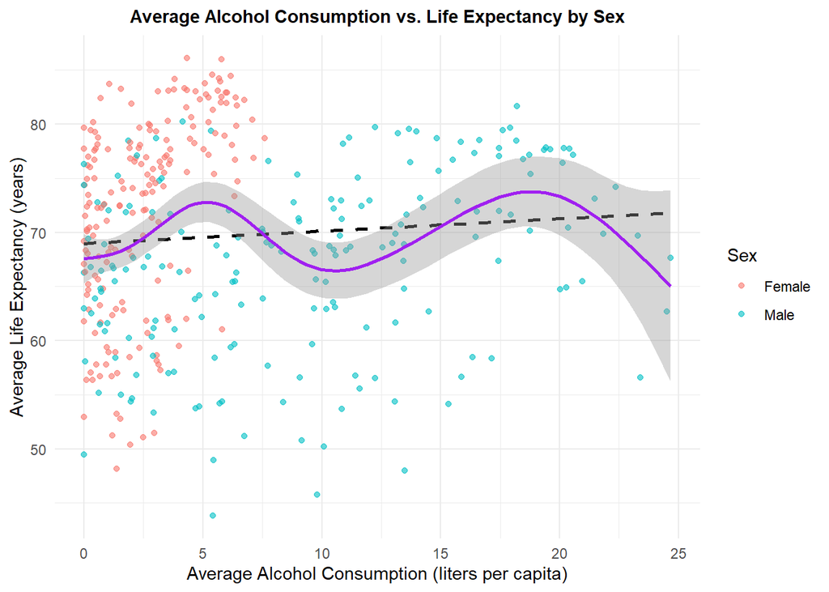